# Analysis of US Graduate Schools Admission + Predictive Modelling

```
                                                                                 Created By Kam Wing Sze, Cathy
```

This analysis aims to (1) provide insights on the selection process of postgraduate admission, (2) reveal the subtle correlations between different academic factors and the chance of admission and; (3) use linear regression and XG boost algorithms to create predictive models to predict the successful chance of admit. At the end of the analysis, I also created a pseudo student academic profile to serve as a dummy to predict whether he/she can successfully getting admitted into a master's degree.

Source: Kaggle, https://www.kaggle.com/mohansacharya/graduate-admissions

Data Credit: Mohan S Acharya, Asfia Armaan, Aneeta S Antony : A Comparison of Regression Models for Prediction of Graduate Admissions, IEEE International Conference on Computational Intelligence in Data Science 2019

# 1. Load in Data

Import numpy, pandas and matplotlib libraries, and load data.

The dataset contains several parameters which are considered important for the Masters Programs application. The feature columns of those are listed as below :

• GRE Scores ( out of 340 )

• TOEFL Scores ( out of 120 )

• University Rating ( out of 5 )

• Statement of Purpose ( out of 5 )

• Letter of Recommendation ( out of 5 )

• Cumulative GPA ( out of 10 )

• Research Experience ( either 0 or 1 )

• Chance of Admit ( ranging from 0 to 1 ) is the Target Variable

```python
import pandas as pd
import seaborn as sns
import matplotlib
import matplotlib.pyplot as plt
matplotlib.rcParams['figure.figsize'] = (20, 10)
import numpy as np
from sklearn.model_selection import train_test_split
from sklearn import linear_model
from sklearn.metrics import mean_squared_error, r2_score
import math
import xgboost as xgb
%matplotlib inline
```

```python
df = pd.read_csv("US_graduate_schools_admission_parameters_dataset.csv")
df.describe()
df
```

|  | Serial No. | GRE Score | TOEFL Score | University Rating | SOP | LOR | CGPA | Research | Chance of Admit |
| --- | --- | --- | --- | --- | --- | --- | --- | --- | --- |
| 0 | 1 | 337 | 118 | 4 | 4.5 | 4.5 | 9.65 | 1 | 0.92 |
| 1 | 2 | 324 | 107 | 4 | 4.0 | 4.5 | 8.87 | 1 | 0.76 |
| 2 | 3 | 316 | 104 | 3 | 3.0 | 3.5 | 8.00 | 1 | 0.72 |
| 3 | 4 | 322 | 110 | 3 | 3.5 | 2.5 | 8.67 | 1 | 0.80 |
| 4 | 5 | 314 | 103 | 2 | 2.0 | 3.0 | 8.21 | 0 | 0.65 |
| ... | ... | ... | ... | ... | ... | ... | ... | ... | ... |
| 395 | 396 | 324 | 110 | 3 | 3.5 | 3.5 | 9.04 | 1 | 0.82 |
| 396 | 397 | 325 | 107 | 3 | 3.0 | 3.5 | 9.11 | 1 | 0.84 |
| 397 | 398 | 330 | 116 | 4 | 5.0 | 4.5 | 9.45 | 1 | 0.91 |
| 398 | 399 | 312 | 103 | 3 | 3.5 | 4.0 | 8.78 | 0 | 0.67 |
| 399 | 400 | 333 | 117 | 4 | 5.0 | 4.0 | 9.66 | 1 | 0.95 |

400 rows × 9 columns

# 2. Data Cleaning

Delete the first column (Serial No.) since it is irrelevant to our target column, and there is already a pre-assigned ID no. for each entry by default.

```python
new_df = df.drop(columns=['Serial No.'], axis =1)
new_df.head()
new_df["GRE Score"] = new_df["GRE Score"].astype(int)
new_df["Chance of Admit "] = new_df["Chance of Admit "].astype(float)
```

This dataset is good because there are no missing values.

```python
missing_values = new_df.isnull().sum()
missing_values
```

```
GRE Score            0
TOEFL Score          0
University Rating    0
SOP                  0
LOR                  0
CGPA                 0
Research             0
Chance of Admit      0
dtype: int64
```

```python
new_df
```

|  | GRE Score | TOEFL Score | University Rating | SOP | LOR | CGPA | Research | Chance of Admit |
| --- | --- | --- | --- | --- | --- | --- | --- | --- |
| 0 | 337 | 118 | 4 | 4.5 | 4.5 | 9.65 | 1 | 0.92 |
| 1 | 324 | 107 | 4 | 4.0 | 4.5 | 8.87 | 1 | 0.76 |
| 2 | 316 | 104 | 3 | 3.0 | 3.5 | 8.00 | 1 | 0.72 |
| 3 | 322 | 110 | 3 | 3.5 | 2.5 | 8.67 | 1 | 0.80 |
| 4 | 314 | 103 | 2 | 2.0 | 3.0 | 8.21 | 0 | 0.65 |
| ... | ... | ... | ... | ... | ... | ... | ... | ... |
| 395 | 324 | 110 | 3 | 3.5 | 3.5 | 9.04 | 1 | 0.82 |
| 396 | 325 | 107 | 3 | 3.0 | 3.5 | 9.11 | 1 | 0.84 |
| 397 | 330 | 116 | 4 | 5.0 | 4.5 | 9.45 | 1 | 0.91 |
| 398 | 312 | 103 | 3 | 3.5 | 4.0 | 8.78 | 0 | 0.67 |
| 399 | 333 | 117 | 4 | 5.0 | 4.0 | 9.66 | 1 | 0.95 |

400 rows × 8 columns

# 3. Data Visualization

```python
matplotlib.rcParams["figure.figsize"] = (20, 10)
```

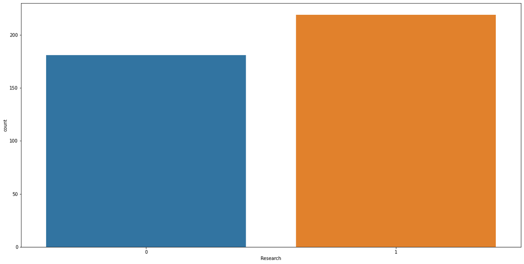

```python
sns.countplot(x="Research", data=new_df)
```

# 3.2 The overall distribution of the GRE Score

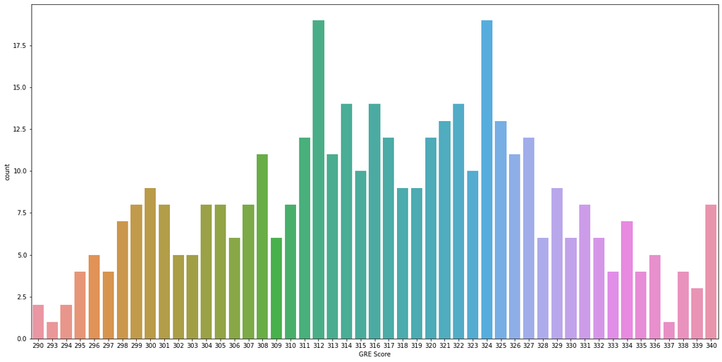

```python
sns.countplot(x="GRE Score", data=new_df)
```

# 3.3 The overall distribution of the TOEFL Score

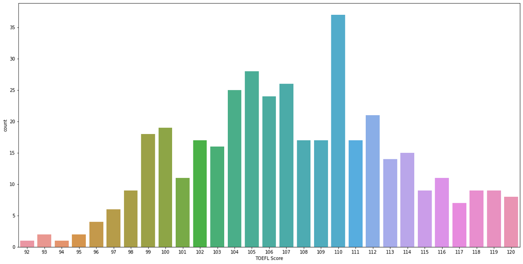

```python
sns.countplot(x="TOEFL Score", data=new_df)
```

# 3.4 To show the overall distribution of the 'University Rating'

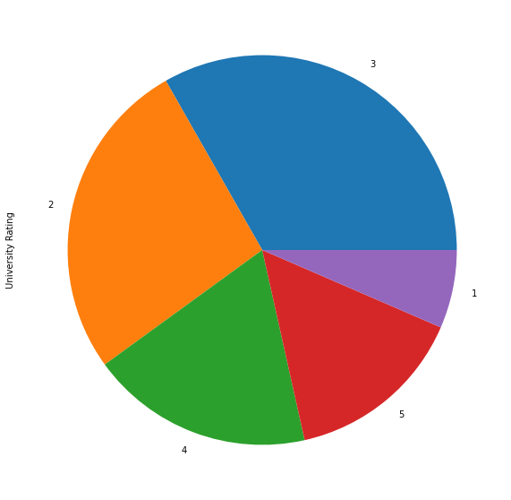

```python
new_df['University Rating'].value_counts().plot(kind = 'pie')
```

# 3.5 Detailed Data Breakdown

Plot histograms for 4 main academic achievement to show the overall distribution of the applicants' academic strength.

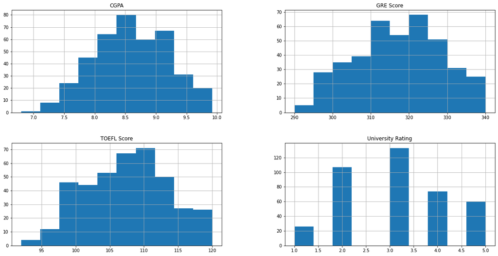

```python
df[['GRE Score','TOEFL Score','University Rating','CGPA']].hist()

plt.show()
```

# 4. Bivariate Analysis

4.1 To show the correlation of different academic achievements and Chance of admit by heatmap.

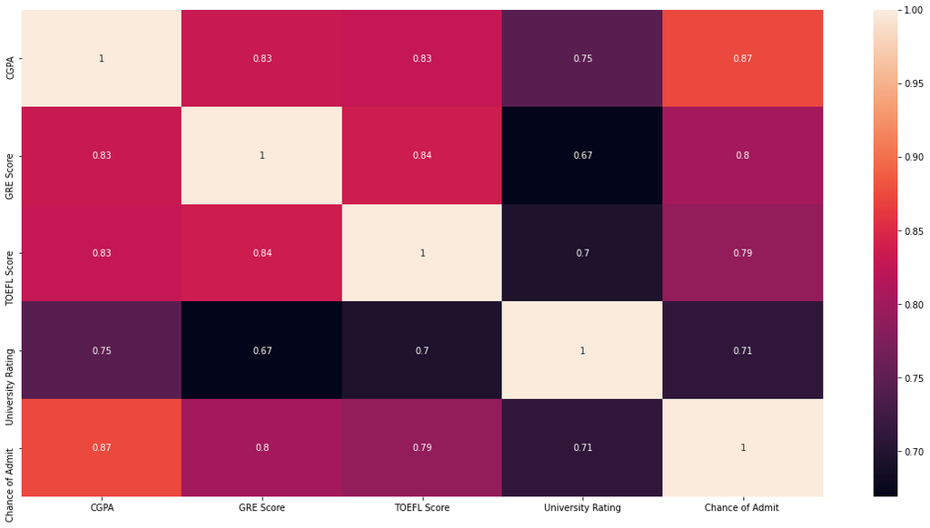

```python
plt.subplots(figsize=(20, 10))

correlation_matrix = new_df[["CGPA","GRE Score","TOEFL Score","University Rating", "Chance of Admit "]].corr()

sns.heatmap(correlation_matrix,annot=True)
```

# 4.2 To show the correlation of different academic achievements

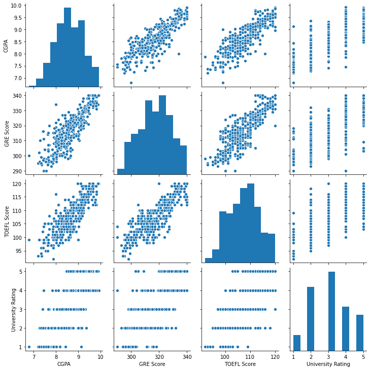

```python
sns.pairplot(new_df[["CGPA","GRE Score","TOEFL Score","University Rating"]])
```

# 4.3 To show the detailed correlation between individual academic achievements and chance of admit by scatter plot

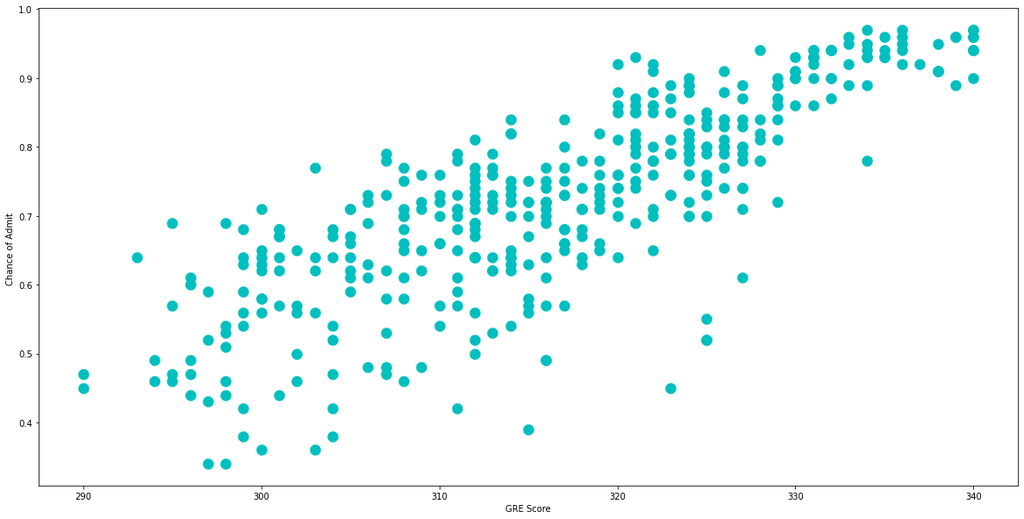

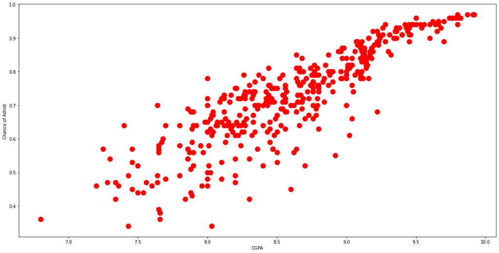

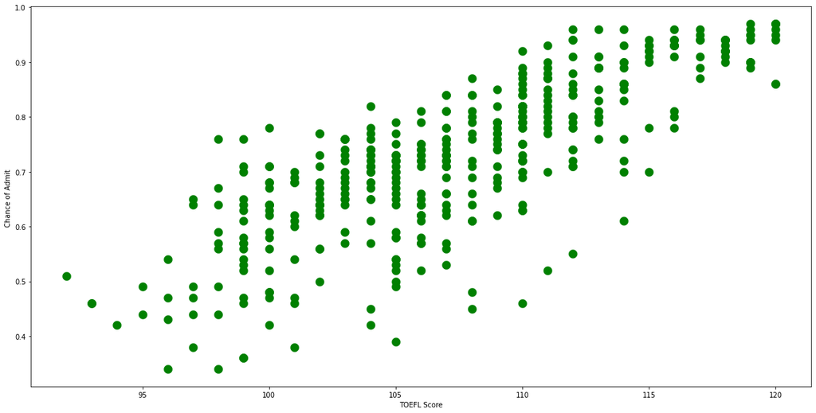

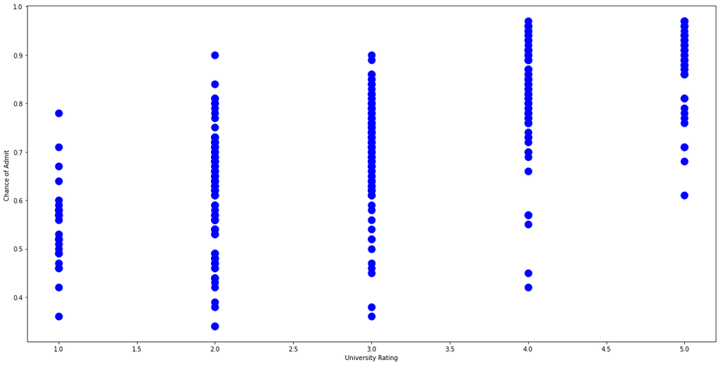

```python
df.plot(kind='scatter', x='GRE Score', y='Chance of Admit ', color='c', linewidth = 8)
plt.xlabel("GRE Score")
plt.ylabel("Chance of Admit ")
plt.show()
df.plot(kind='scatter', x='CGPA', y='Chance of Admit ', color='r', linewidth = 8)
plt.xlabel("CGPA")
plt.ylabel("Chance of Admit ")
plt.show()
df.plot(kind='scatter', x= 'TOEFL Score', y='Chance of Admit ', color='g', linewidth = 8)
plt.xlabel("TOEFL Score")
plt.ylabel("Chance of Admit ")
plt.show()
df.plot(kind='scatter', x= 'University Rating', y='Chance of Admit ', color='b', linewidth = 8)
plt.xlabel("University Rating")
plt.ylabel("Chance of Admit ")
plt.show()
```

# 5. Feature Scaling

5.1 Import MinMaxScaler function and select the feature columns to be scaled.

```python
X = new_df.iloc[:,0:7]
Y = new_df.iloc[:,7]
```

```python
X
```

|  | GRE Score | TOEFL Score | University Rating | SOP | LOR | CGPA | Research |
| --- | --- | --- | --- | --- | --- | --- | --- |
| 0 | 337 | 118 | 4 | 4.5 | 4.5 | 9.65 | 1 |
| 1 | 324 | 107 | 4 | 4.0 | 4.5 | 8.87 | 1 |
| 2 | 316 | 104 | 3 | 3.0 | 3.5 | 8.00 | 1 |
| 3 | 322 | 110 | 3 | 3.5 | 2.5 | 8.67 | 1 |
| 4 | 314 | 103 | 2 | 2.0 | 3.0 | 8.21 | 0 |
| ... | ... | ... | ... | ... | ... | ... | ... |
| 395 | 324 | 110 | 3 | 3.5 | 3.5 | 9.04 | 1 |
| 396 | 325 | 107 | 3 | 3.0 | 3.5 | 9.11 | 1 |
| 397 | 330 | 116 | 4 | 5.0 | 4.5 | 9.45 | 1 |
| 398 | 312 | 103 | 3 | 3.5 | 4.0 | 8.78 | 0 |
| 399 | 333 | 117 | 4 | 5.0 | 4.0 | 9.66 | 1 |

400 rows × 7 columns

```python
from sklearn.preprocessing import MinMaxScaler
scaler = MinMaxScaler(feature_range=(0, 1))
rescaledX = scaler.fit_transform(X)
```

```python
rescaledX
```

```
array([[0.94      , 0.92857143, 0.75      , ..., 0.875     , 0.91346154,
        1.        ],
       [0.68      , 0.53571429, 0.75      , ..., 0.875     , 0.66346154,
        1.        ],
       [0.52      , 0.42857143, 0.5       , ..., 0.625     , 0.38461538,
        1.        ],
       ...,
       [0.8       , 0.85714286, 0.75      , ..., 0.875     , 0.84935897,
        1.        ],
       [0.44      , 0.39285714, 0.5       , ..., 0.75      , 0.63461538,
        0.        ],
       [0.86      , 0.89285714, 0.75      , ..., 0.75      , 0.91666667,
        1.        ]])
```

# 6. Spliting the data into training data and testing data

```python
from sklearn.model_selection import train_test_split
from sklearn import linear_model
from sklearn.metrics import mean_squared_error, r2_score
import math
```

```python
X_train, X_test, y_train, y_test = train_test_split(rescaledX,Y,test_size=0.2,random_state=42 )
```

# 6.1 Running a Linear Regression model

Create a linear regression object, train the model using the training sets and make predictions using the testing set

```python
regr = linear_model.LinearRegression()

regr.fit(X_train, y_train)

y_pred = regr.predict(X_test)
```

Examine the coefficients, mean squared error and variance score based on the linear regression model

```python
print('Coefficients: \n', regr.coef_)

print(f"Mean squared error:{mean_squared_error(y_test, y_pred): .2f}")

print(f"Root Mean squared error: {math.sqrt(mean_squared_error(y_test, y_pred)) :.2f}")

print(f'Variance score: {r2_score(y_test, y_pred):.2f}')
```

```
Coefficients:
 [ 0.09312548  0.07626324  0.0295098  -0.00117097  0.06308097  0.35776778
  0.02222705]
Mean squared error: 0.00
Root Mean squared error: 0.07
Variance score: 0.82
```

# 6.2 Running a XGBoost model

```python
import xgboost as xgb
```

```python
regr_xgb = xgb.XGBRegressor()
```

```python
regr_xgb = xgb.XGBRegressor()

regr_xgb.fit(X_train, y_train)

y_pred = regr_xgb.predict(X_test)
```

```python
print('Coefficients: \n', regr.coef_)

print(f"Mean squared error:{mean_squared_error(y_test, y_pred): .2f}")

print(f"Root Mean squared error: {math.sqrt(mean_squared_error(y_test, y_pred)) :.2f}")

print(f'Variance score: {r2_score(y_test, y_pred):.2f}')
```

```
Coefficients:
 [ 0.09312548  0.07626324  0.0295098  -0.00117097  0.06308097  0.35776778
  0.02222705]
Mean squared error: 0.01
Root Mean squared error: 0.08
Variance score: 0.78
```

```python
student = [370, 110, 3, 3.5, 3.5, 8.84, 1]
```

```python
student = np.asarray(student)
```

```python
rescaledX_student = scaler.transform(student.reshape(1,-1))
```

```python
rescaledX_student
```

```
array([[1.6       , 0.64285714, 0.5       , 0.625     , 0.625     ,
        0.65384615, 1.        ]])
```

```python
regr_xgb.predict(rescaledX_student)
```

```
array([0.7915152], dtype=float32)
```

```python
student_pred = regr_xgb.predict(rescaledX_student)
```

```python
if student_pred[0] > 0.72:
    print("Congratulations! You're very likely to be successful!")

else:
    print("Emm...maybe you need to work harder to secure the admission.")
```

```
Congratulations! You're very likely to be successful!
```